# Optimal Treatment Analysis

## Outcome Variable

**Outcome Variable:** ever_wasted

## Predictor Variables

**Intervention Variable:** vagbrth

**Adjustment Set:**

- arm
- sex
- W_mage
- meducyrs
- feducyrs
- W_mhtcm
- W_mwtkg
- W_mbmi
- single
- brthmon
- W_parity
- delta_W_mage
- delta_meducyrs
- delta_feducyrs
- delta_W_mhtcm
- delta_W_mwtkg
- delta_W_mbmi
- delta_single
- delta_brthmon
- delta_W_parity

## Stratifying Variables

The analysis was stratified on these variable(s):

- agecat
- studyid
- country

## Data Summary

| agecat | studyid | country | vagbrth | ever_wasted | n_cell | n |
| --- | --- | --- | --- | --- | --- | --- |
| 0-24 months (no birth wast) | ki1000108-CMC-V-BCS-2002 | INDIA | 0 | 0 | 17 | 368 |
| 0-24 months (no birth wast) | ki1000108-CMC-V-BCS-2002 | INDIA | 0 | 1 | 8 | 368 |
| 0-24 months (no birth wast) | ki1000108-CMC-V-BCS-2002 | INDIA | 1 | 0 | 185 | 368 |
| 0-24 months (no birth wast) | ki1000108-CMC-V-BCS-2002 | INDIA | 1 | 1 | 158 | 368 |
| 0-24 months (no birth wast) | ki1000108-IRC | INDIA | 0 | 0 | 38 | 409 |
| 0-24 months (no birth wast) | ki1000108-IRC | INDIA | 0 | 1 | 32 | 409 |
| 0-24 months (no birth wast) | ki1000108-IRC | INDIA | 1 | 0 | 158 | 409 |
| 0-24 months (no birth wast) | ki1000108-IRC | INDIA | 1 | 1 | 181 | 409 |
| 0-24 months (no birth wast) | ki1017093b-PROVIDE | BANGLADESH | 0 | 0 | 132 | 687 |
| 0-24 months (no birth wast) | ki1017093b-PROVIDE | BANGLADESH | 0 | 1 | 27 | 687 |
| 0-24 months (no birth wast) | ki1017093b-PROVIDE | BANGLADESH | 1 | 0 | 433 | 687 |
| 0-24 months (no birth wast) | ki1017093b-PROVIDE | BANGLADESH | 1 | 1 | 95 | 687 |
| 0-24 months (no birth wast) | ki1017093c-NIH-Crypto | BANGLADESH | 0 | 0 | 181 | 496 |
| 0-24 months (no birth wast) | ki1017093c-NIH-Crypto | BANGLADESH | 0 | 1 | 21 | 496 |
| 0-24 months (no birth wast) | ki1017093c-NIH-Crypto | BANGLADESH | 1 | 0 | 245 | 496 |
| 0-24 months (no birth wast) | ki1017093c-NIH-Crypto | BANGLADESH | 1 | 1 | 49 | 496 |
| 0-24 months (no birth wast) | ki1066203-TanzaniaChild2 | TANZANIA, UNITED REPUBLIC OF | 0 | 0 | 174 | 2355 |
| 0-24 months (no birth wast) | ki1066203-TanzaniaChild2 | TANZANIA, UNITED REPUBLIC OF | 0 | 1 | 38 | 2355 |
| 0-24 months (no birth wast) | ki1066203-TanzaniaChild2 | TANZANIA, UNITED REPUBLIC OF | 1 | 0 | 1712 | 2355 |
| 0-24 months (no birth wast) | ki1066203-TanzaniaChild2 | TANZANIA, UNITED REPUBLIC OF | 1 | 1 | 431 | 2355 |
| 0-24 months (no birth wast) | ki1119695-PROBIT | BELARUS | 0 | 0 | 792 | 8113 |
| 0-24 months (no birth wast) | ki1119695-PROBIT | BELARUS | 0 | 1 | 55 | 8113 |
| 0-24 months (no birth wast) | ki1119695-PROBIT | BELARUS | 1 | 0 | 6824 | 8113 |
| 0-24 months (no birth wast) | ki1119695-PROBIT | BELARUS | 1 | 1 | 442 | 8113 |
| 0-24 months (no birth wast) | ki1126311-ZVITAMBO | ZIMBABWE | 0 | 0 | 941 | 12356 |
| 0-24 months (no birth wast) | ki1126311-ZVITAMBO | ZIMBABWE | 0 | 1 | 97 | 12356 |
| 0-24 months (no birth wast) | ki1126311-ZVITAMBO | ZIMBABWE | 1 | 0 | 10070 | 12356 |
| 0-24 months (no birth wast) | ki1126311-ZVITAMBO | ZIMBABWE | 1 | 1 | 1248 | 12356 |
| 0-24 months (no birth wast) | kiGH5241-JiVitA-3 | BANGLADESH | 0 | 0 | 653 | 12953 |
| 0-24 months (no birth wast) | kiGH5241-JiVitA-3 | BANGLADESH | 0 | 1 | 88 | 12953 |

[output cut: 78 more lines]

The following strata were considered:

- agecat: 0-24 months (no birth wast), studyid: ki1000108-CMC-V-BCS-2002, country: INDIA
- agecat: 0-24 months (no birth wast), studyid: ki1000108-IRC, country: INDIA
- agecat: 0-24 months (no birth wast), studyid: ki1017093b-PROVIDE, country: BANGLADESH
- agecat: 0-24 months (no birth wast), studyid: ki1017093c-NIH-Crypto, country: BANGLADESH
- agecat: 0-24 months (no birth wast), studyid: ki1066203-TanzaniaChild2, country: TANZANIA, UNITED REPUBLIC OF
- agecat: 0-24 months (no birth wast), studyid: ki1119695-PROBIT, country: BELARUS
- agecat: 0-24 months (no birth wast), studyid: ki1126311-ZVITAMBO, country: ZIMBABWE
- agecat: 0-24 months (no birth wast), studyid: kiGH5241-JiVitA-3, country: BANGLADESH
- agecat: 0-24 months (no birth wast), studyid: kiGH5241-JiVitA-4, country: BANGLADESH
- agecat: 0-6 months (no birth wast), studyid: ki1000108-CMC-V-BCS-2002, country: INDIA
- agecat: 0-6 months (no birth wast), studyid: ki1000108-IRC, country: INDIA
- agecat: 0-6 months (no birth wast), studyid: ki1017093b-PROVIDE, country: BANGLADESH
- agecat: 0-6 months (no birth wast), studyid: ki1017093c-NIH-Crypto, country: BANGLADESH
- agecat: 0-6 months (no birth wast), studyid: ki1066203-TanzaniaChild2, country: TANZANIA, UNITED REPUBLIC OF
- agecat: 0-6 months (no birth wast), studyid: ki1119695-PROBIT, country: BELARUS
- agecat: 0-6 months (no birth wast), studyid: ki1126311-ZVITAMBO, country: ZIMBABWE
- agecat: 0-6 months (no birth wast), studyid: kiGH5241-JiVitA-3, country: BANGLADESH
- agecat: 0-6 months (no birth wast), studyid: kiGH5241-JiVitA-4, country: BANGLADESH
- agecat: 6-24 months, studyid: ki1000108-CMC-V-BCS-2002, country: INDIA
- agecat: 6-24 months, studyid: ki1000108-IRC, country: INDIA
- agecat: 6-24 months, studyid: ki1017093b-PROVIDE, country: BANGLADESH
- agecat: 6-24 months, studyid: ki1017093c-NIH-Crypto, country: BANGLADESH
- agecat: 6-24 months, studyid: ki1066203-TanzaniaChild2, country: TANZANIA, UNITED REPUBLIC OF
- agecat: 6-24 months, studyid: ki1119695-PROBIT, country: BELARUS
- agecat: 6-24 months, studyid: ki1126311-ZVITAMBO, country: ZIMBABWE
- agecat: 6-24 months, studyid: kiGH5241-JiVitA-3, country: BANGLADESH
- agecat: 6-24 months, studyid: kiGH5241-JiVitA-4, country: BANGLADESH

### Dropped Strata

Some strata were dropped due to rare outcomes:

- agecat: 0-6 months (no birth wast), studyid: ki1017093c-NIH-Crypto, country: BANGLADESH
- agecat: 0-6 months (no birth wast), studyid: kiGH5241-JiVitA-4, country: BANGLADESH
- agecat: 6-24 months, studyid: ki1000108-CMC-V-BCS-2002, country: INDIA

## Methods Detail

We’re interested in the causal parameters $E[Y_a]$ for all values of $a \in \mathcal{A}$. These parameters represent the mean outcome if, possibly contrary to fact, we intervened to set all units to have $A=a$. Under the randomization and positivity assumptions, these are identified by the statistical parameters $\psi_a=E_W[E_{Y|A,W}(Y|A=a,W)]$. In addition, we’re interested in the mean of $Y$, $E[Y]$ under no intervention (the observed mean). We will estimate these parameters by using SuperLearner to fit the relevant likelihood factors – $E_{Y|A,W}(Y|A=a,W)$ and $p(A=a|W)$, and then updating our likelihood fit using a joint TMLE.

For unadjusted analyses ($W=\{\}$), initial likelihoods were estimated using Lrnr_glm to estimate the simple $E(Y|A)$ and Lrnr_mean to estimate $p(A)$. For adjusted analyses, a small library containing Lrnr_glmnet, Lrnr_xgboost, and Lrnr_mean was used.

Having estimated these parameters, we will then use the delta method to estimate relative risks and attributable risks relative to a prespecified baseline level of $A$.

# Results Detail

## Results Plots

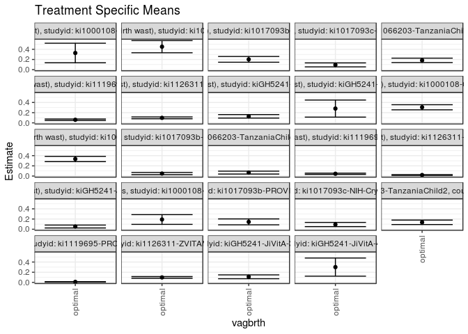

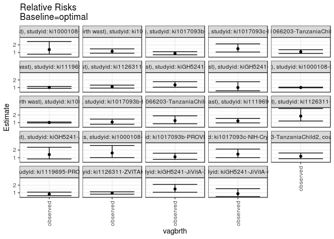

## Results Table

### Parameter: TSM

| agecat | studyid | country | intervention_level | baseline_level | estimate | ci_lower | ci_upper |
| --- | --- | --- | --- | --- | --- | --- | --- |
| 0-24 months (no birth wast) | ki1000108-CMC-V-BCS-2002 | INDIA | optimal | NA | 0.3274235 | 0.1357199 | 0.5191270 |
| 0-24 months (no birth wast) | ki1000108-IRC | INDIA | optimal | NA | 0.4508862 | 0.3316953 | 0.5700771 |
| 0-24 months (no birth wast) | ki1017093b-PROVIDE | BANGLADESH | optimal | NA | 0.2022411 | 0.1458538 | 0.2586284 |
| 0-24 months (no birth wast) | ki1017093c-NIH-Crypto | BANGLADESH | optimal | NA | 0.0940239 | 0.0552063 | 0.1328415 |
| 0-24 months (no birth wast) | ki1066203-TanzaniaChild2 | TANZANIA, UNITED REPUBLIC OF | optimal | NA | 0.1829015 | 0.1394467 | 0.2263563 |
| 0-24 months (no birth wast) | ki1119695-PROBIT | BELARUS | optimal | NA | 0.0604569 | 0.0458468 | 0.0750669 |
| 0-24 months (no birth wast) | ki1126311-ZVITAMBO | ZIMBABWE | optimal | NA | 0.0985349 | 0.0804999 | 0.1165699 |
| 0-24 months (no birth wast) | kiGH5241-JiVitA-3 | BANGLADESH | optimal | NA | 0.1281542 | 0.0941214 | 0.1621869 |
| 0-24 months (no birth wast) | kiGH5241-JiVitA-4 | BANGLADESH | optimal | NA | 0.2804828 | 0.1131803 | 0.4477853 |
| 0-6 months (no birth wast) | ki1000108-CMC-V-BCS-2002 | INDIA | optimal | NA | 0.3058820 | 0.2558423 | 0.3559217 |
| 0-6 months (no birth wast) | ki1000108-IRC | INDIA | optimal | NA | 0.3347058 | 0.2830831 | 0.3863285 |
| 0-6 months (no birth wast) | ki1017093b-PROVIDE | BANGLADESH | optimal | NA | 0.0490411 | 0.0273025 | 0.0707797 |
| 0-6 months (no birth wast) | ki1066203-TanzaniaChild2 | TANZANIA, UNITED REPUBLIC OF | optimal | NA | 0.0677037 | 0.0393140 | 0.0960935 |
| 0-6 months (no birth wast) | ki1119695-PROBIT | BELARUS | optimal | NA | 0.0449566 | 0.0327769 | 0.0571364 |
| 0-6 months (no birth wast) | ki1126311-ZVITAMBO | ZIMBABWE | optimal | NA | 0.0201599 | 0.0113160 | 0.0290038 |
| 0-6 months (no birth wast) | kiGH5241-JiVitA-3 | BANGLADESH | optimal | NA | 0.0534853 | 0.0252236 | 0.0817471 |
| 6-24 months | ki1000108-IRC | INDIA | optimal | NA | 0.1912062 | 0.0955480 | 0.2868644 |
| 6-24 months | ki1017093b-PROVIDE | BANGLADESH | optimal | NA | 0.1445636 | 0.0866200 | 0.2025071 |
| 6-24 months | ki1017093c-NIH-Crypto | BANGLADESH | optimal | NA | 0.0925452 | 0.0514290 | 0.1336614 |
| 6-24 months | ki1066203-TanzaniaChild2 | TANZANIA, UNITED REPUBLIC OF | optimal | NA | 0.1357288 | 0.0918157 | 0.1796418 |
| 6-24 months | ki1119695-PROBIT | BELARUS | optimal | NA | 0.0100764 | 0.0063922 | 0.0137606 |
| 6-24 months | ki1126311-ZVITAMBO | ZIMBABWE | optimal | NA | 0.0977461 | 0.0809712 | 0.1145211 |
| 6-24 months | kiGH5241-JiVitA-3 | BANGLADESH | optimal | NA | 0.1103885 | 0.0726029 | 0.1481742 |
| 6-24 months | kiGH5241-JiVitA-4 | BANGLADESH | optimal | NA | 0.3002697 | 0.1224698 | 0.4780697 |

### Parameter: E(Y)

| agecat | studyid | country | intervention_level | baseline_level | estimate | ci_lower | ci_upper |
| --- | --- | --- | --- | --- | --- | --- | --- |
| 0-24 months (no birth wast) | ki1000108-CMC-V-BCS-2002 | INDIA | observed | NA | 0.4510870 | 0.4001777 | 0.5019962 |
| 0-24 months (no birth wast) | ki1000108-IRC | INDIA | observed | NA | 0.5207824 | 0.4723080 | 0.5692568 |
| 0-24 months (no birth wast) | ki1017093b-PROVIDE | BANGLADESH | observed | NA | 0.1775837 | 0.1489858 | 0.2061816 |
| 0-24 months (no birth wast) | ki1017093c-NIH-Crypto | BANGLADESH | observed | NA | 0.1411290 | 0.1104588 | 0.1717993 |
| 0-24 months (no birth wast) | ki1066203-TanzaniaChild2 | TANZANIA, UNITED REPUBLIC OF | observed | NA | 0.1991507 | 0.1830179 | 0.2152836 |
| 0-24 months (no birth wast) | ki1119695-PROBIT | BELARUS | observed | NA | 0.0612597 | 0.0474556 | 0.0750638 |
| 0-24 months (no birth wast) | ki1126311-ZVITAMBO | ZIMBABWE | observed | NA | 0.1088540 | 0.1033621 | 0.1143459 |
| 0-24 months (no birth wast) | kiGH5241-JiVitA-3 | BANGLADESH | observed | NA | 0.1743226 | 0.1664929 | 0.1821522 |
| 0-24 months (no birth wast) | kiGH5241-JiVitA-4 | BANGLADESH | observed | NA | 0.2813559 | 0.2510454 | 0.3116665 |
| 0-6 months (no birth wast) | ki1000108-CMC-V-BCS-2002 | INDIA | observed | NA | 0.3085714 | 0.2601110 | 0.3570318 |
| 0-6 months (no birth wast) | ki1000108-IRC | INDIA | observed | NA | 0.3410256 | 0.2939169 | 0.3881343 |
| 0-6 months (no birth wast) | ki1017093b-PROVIDE | BANGLADESH | observed | NA | 0.0527086 | 0.0359384 | 0.0694789 |
| 0-6 months (no birth wast) | ki1066203-TanzaniaChild2 | TANZANIA, UNITED REPUBLIC OF | observed | NA | 0.0860673 | 0.0747182 | 0.0974164 |
| 0-6 months (no birth wast) | ki1119695-PROBIT | BELARUS | observed | NA | 0.0550194 | 0.0412334 | 0.0688054 |
| 0-6 months (no birth wast) | ki1126311-ZVITAMBO | ZIMBABWE | observed | NA | 0.0374284 | 0.0339371 | 0.0409198 |
| 0-6 months (no birth wast) | kiGH5241-JiVitA-3 | BANGLADESH | observed | NA | 0.0754024 | 0.0701103 | 0.0806945 |
| 6-24 months | ki1000108-IRC | INDIA | observed | NA | 0.3097561 | 0.2649438 | 0.3545684 |
| 6-24 months | ki1017093b-PROVIDE | BANGLADESH | observed | NA | 0.1609756 | 0.1319065 | 0.1900447 |
| 6-24 months | ki1017093c-NIH-Crypto | BANGLADESH | observed | NA | 0.1355932 | 0.1046749 | 0.1665115 |
| 6-24 months | ki1066203-TanzaniaChild2 | TANZANIA, UNITED REPUBLIC OF | observed | NA | 0.1608216 | 0.1447012 | 0.1769421 |
| 6-24 months | ki1119695-PROBIT | BELARUS | observed | NA | 0.0082759 | 0.0065972 | 0.0099545 |
| 6-24 months | ki1126311-ZVITAMBO | ZIMBABWE | observed | NA | 0.0936351 | 0.0880903 | 0.0991799 |
| 6-24 months | kiGH5241-JiVitA-3 | BANGLADESH | observed | NA | 0.1651010 | 0.1559407 | 0.1742613 |
| 6-24 months | kiGH5241-JiVitA-4 | BANGLADESH | observed | NA | 0.2653749 | 0.2359283 | 0.2948215 |

### Parameter: RR

| agecat | studyid | country | intervention_level | baseline_level | estimate | ci_lower | ci_upper |
| --- | --- | --- | --- | --- | --- | --- | --- |
| 0-24 months (no birth wast) | ki1000108-CMC-V-BCS-2002 | INDIA | observed | optimal | 1.3776868 | 0.7802098 | 2.432706 |
| 0-24 months (no birth wast) | ki1000108-IRC | INDIA | observed | optimal | 1.1550197 | 0.9071651 | 1.470593 |
| 0-24 months (no birth wast) | ki1017093b-PROVIDE | BANGLADESH | observed | optimal | 0.8780792 | 0.6966178 | 1.106809 |
| 0-24 months (no birth wast) | ki1017093c-NIH-Crypto | BANGLADESH | observed | optimal | 1.5009907 | 1.0604534 | 2.124538 |
| 0-24 months (no birth wast) | ki1066203-TanzaniaChild2 | TANZANIA, UNITED REPUBLIC OF | observed | optimal | 1.0888415 | 0.8681140 | 1.365691 |
| 0-24 months (no birth wast) | ki1119695-PROBIT | BELARUS | observed | optimal | 1.0132797 | 0.8950259 | 1.147158 |
| 0-24 months (no birth wast) | ki1126311-ZVITAMBO | ZIMBABWE | observed | optimal | 1.1047248 | 0.9263027 | 1.317514 |
| 0-24 months (no birth wast) | kiGH5241-JiVitA-3 | BANGLADESH | observed | optimal | 1.3602566 | 1.0462916 | 1.768434 |
| 0-24 months (no birth wast) | kiGH5241-JiVitA-4 | BANGLADESH | observed | optimal | 1.0031130 | 0.5723577 | 1.758054 |
| 0-6 months (no birth wast) | ki1000108-CMC-V-BCS-2002 | INDIA | observed | optimal | 1.0087924 | 0.9658188 | 1.053678 |
| 0-6 months (no birth wast) | ki1000108-IRC | INDIA | observed | optimal | 1.0188818 | 0.9547060 | 1.087371 |
| 0-6 months (no birth wast) | ki1017093b-PROVIDE | BANGLADESH | observed | optimal | 1.0747852 | 0.7919285 | 1.458671 |
| 0-6 months (no birth wast) | ki1066203-TanzaniaChild2 | TANZANIA, UNITED REPUBLIC OF | observed | optimal | 1.2712347 | 0.8535169 | 1.893387 |
| 0-6 months (no birth wast) | ki1119695-PROBIT | BELARUS | observed | optimal | 1.2238333 | 0.9638714 | 1.553908 |
| 0-6 months (no birth wast) | ki1126311-ZVITAMBO | ZIMBABWE | observed | optimal | 1.8565788 | 1.2100011 | 2.848663 |
| 0-6 months (no birth wast) | kiGH5241-JiVitA-3 | BANGLADESH | observed | optimal | 1.4097771 | 0.8377509 | 2.372390 |
| 6-24 months | ki1000108-IRC | INDIA | observed | optimal | 1.6200111 | 1.0119793 | 2.593369 |
| 6-24 months | ki1017093b-PROVIDE | BANGLADESH | observed | optimal | 1.1135283 | 0.7783673 | 1.593008 |
| 6-24 months | ki1017093c-NIH-Crypto | BANGLADESH | observed | optimal | 1.4651570 | 1.0085522 | 2.128482 |
| 6-24 months | ki1066203-TanzaniaChild2 | TANZANIA, UNITED REPUBLIC OF | observed | optimal | 1.1848751 | 0.8694770 | 1.614682 |
| 6-24 months | ki1119695-PROBIT | BELARUS | observed | optimal | 0.8213087 | 0.6209353 | 1.086342 |
| 6-24 months | ki1126311-ZVITAMBO | ZIMBABWE | observed | optimal | 0.9579415 | 0.8156237 | 1.125092 |
| 6-24 months | kiGH5241-JiVitA-3 | BANGLADESH | observed | optimal | 1.4956351 | 1.0677534 | 2.094982 |
| 6-24 months | kiGH5241-JiVitA-4 | BANGLADESH | observed | optimal | 0.8837884 | 0.5084046 | 1.536339 |

### Parameter: PAR

| agecat | studyid | country | intervention_level | baseline_level | estimate | ci_lower | ci_upper |
| --- | --- | --- | --- | --- | --- | --- | --- |
| 0-24 months (no birth wast) | ki1000108-CMC-V-BCS-2002 | INDIA | optimal | NA | 0.1236635 | -0.0622969 | 0.3096239 |
| 0-24 months (no birth wast) | ki1000108-IRC | INDIA | optimal | NA | 0.0698962 | -0.0387933 | 0.1785858 |
| 0-24 months (no birth wast) | ki1017093b-PROVIDE | BANGLADESH | optimal | NA | -0.0246574 | -0.0715492 | 0.0222344 |
| 0-24 months (no birth wast) | ki1017093c-NIH-Crypto | BANGLADESH | optimal | NA | 0.0471051 | 0.0130347 | 0.0811755 |
| 0-24 months (no birth wast) | ki1066203-TanzaniaChild2 | TANZANIA, UNITED REPUBLIC OF | optimal | NA | 0.0162493 | -0.0252589 | 0.0577574 |
| 0-24 months (no birth wast) | ki1119695-PROBIT | BELARUS | optimal | NA | 0.0008029 | -0.0067268 | 0.0083325 |
| 0-24 months (no birth wast) | ki1126311-ZVITAMBO | ZIMBABWE | optimal | NA | 0.0103191 | -0.0070479 | 0.0276860 |
| 0-24 months (no birth wast) | kiGH5241-JiVitA-3 | BANGLADESH | optimal | NA | 0.0461684 | 0.0124426 | 0.0798942 |
| 0-24 months (no birth wast) | kiGH5241-JiVitA-4 | BANGLADESH | optimal | NA | 0.0008731 | -0.1564827 | 0.1582290 |
| 0-6 months (no birth wast) | ki1000108-CMC-V-BCS-2002 | INDIA | optimal | NA | 0.0026894 | -0.0106269 | 0.0160058 |
| 0-6 months (no birth wast) | ki1000108-IRC | INDIA | optimal | NA | 0.0063198 | -0.0154498 | 0.0280895 |
| 0-6 months (no birth wast) | ki1017093b-PROVIDE | BANGLADESH | optimal | NA | 0.0036675 | -0.0113433 | 0.0186784 |
| 0-6 months (no birth wast) | ki1066203-TanzaniaChild2 | TANZANIA, UNITED REPUBLIC OF | optimal | NA | 0.0183636 | -0.0087226 | 0.0454498 |
| 0-6 months (no birth wast) | ki1119695-PROBIT | BELARUS | optimal | NA | 0.0100628 | -0.0018783 | 0.0220039 |
| 0-6 months (no birth wast) | ki1126311-ZVITAMBO | ZIMBABWE | optimal | NA | 0.0172685 | 0.0084980 | 0.0260391 |
| 0-6 months (no birth wast) | kiGH5241-JiVitA-3 | BANGLADESH | optimal | NA | 0.0219171 | -0.0058912 | 0.0497253 |
| 6-24 months | ki1000108-IRC | INDIA | optimal | NA | 0.1185499 | 0.0279536 | 0.2091463 |
| 6-24 months | ki1017093b-PROVIDE | BANGLADESH | optimal | NA | 0.0164121 | -0.0354437 | 0.0682678 |
| 6-24 months | ki1017093c-NIH-Crypto | BANGLADESH | optimal | NA | 0.0430480 | 0.0074507 | 0.0786453 |
| 6-24 months | ki1066203-TanzaniaChild2 | TANZANIA, UNITED REPUBLIC OF | optimal | NA | 0.0250929 | -0.0170376 | 0.0672233 |
| 6-24 months | ki1119695-PROBIT | BELARUS | optimal | NA | -0.0018006 | -0.0046876 | 0.0010865 |
| 6-24 months | ki1126311-ZVITAMBO | ZIMBABWE | optimal | NA | -0.0041111 | -0.0198348 | 0.0116127 |
| 6-24 months | kiGH5241-JiVitA-3 | BANGLADESH | optimal | NA | 0.0547124 | 0.0174309 | 0.0919940 |
| 6-24 months | kiGH5241-JiVitA-4 | BANGLADESH | optimal | NA | -0.0348948 | -0.2019953 | 0.1322056 |

### Parameter: PAF

| agecat | studyid | country | intervention_level | baseline_level | estimate | ci_lower | ci_upper |
| --- | --- | --- | --- | --- | --- | --- | --- |
| 0-24 months (no birth wast) | ki1000108-CMC-V-BCS-2002 | INDIA | optimal | NA | 0.2741456 | -0.2817065 | 0.5889351 |
| 0-24 months (no birth wast) | ki1000108-IRC | INDIA | optimal | NA | 0.1342139 | -0.1023352 | 0.3200021 |
| 0-24 months (no birth wast) | ki1017093b-PROVIDE | BANGLADESH | optimal | NA | -0.1388495 | -0.4355074 | 0.0965020 |
| 0-24 months (no birth wast) | ki1017093c-NIH-Crypto | BANGLADESH | optimal | NA | 0.3337734 | 0.0570071 | 0.5293093 |
| 0-24 months (no birth wast) | ki1066203-TanzaniaChild2 | TANZANIA, UNITED REPUBLIC OF | optimal | NA | 0.0815927 | -0.1519224 | 0.2677702 |
| 0-24 months (no birth wast) | ki1119695-PROBIT | BELARUS | optimal | NA | 0.0131057 | -0.1172862 | 0.1282803 |
| 0-24 months (no birth wast) | ki1126311-ZVITAMBO | ZIMBABWE | optimal | NA | 0.0947972 | -0.0795607 | 0.2409949 |
| 0-24 months (no birth wast) | kiGH5241-JiVitA-3 | BANGLADESH | optimal | NA | 0.2648446 | 0.0442435 | 0.4345280 |
| 0-24 months (no birth wast) | kiGH5241-JiVitA-4 | BANGLADESH | optimal | NA | 0.0031033 | -0.7471592 | 0.4311892 |
| 0-6 months (no birth wast) | ki1000108-CMC-V-BCS-2002 | INDIA | optimal | NA | 0.0087157 | -0.0353909 | 0.0509434 |
| 0-6 months (no birth wast) | ki1000108-IRC | INDIA | optimal | NA | 0.0185319 | -0.0474429 | 0.0803511 |
| 0-6 months (no birth wast) | ki1017093b-PROVIDE | BANGLADESH | optimal | NA | 0.0695815 | -0.2627403 | 0.3144445 |
| 0-6 months (no birth wast) | ki1066203-TanzaniaChild2 | TANZANIA, UNITED REPUBLIC OF | optimal | NA | 0.2133632 | -0.1716230 | 0.4718459 |
| 0-6 months (no birth wast) | ki1119695-PROBIT | BELARUS | optimal | NA | 0.1828952 | -0.0374828 | 0.3564615 |
| 0-6 months (no birth wast) | ki1126311-ZVITAMBO | ZIMBABWE | optimal | NA | 0.4613749 | 0.1735544 | 0.6489581 |
| 0-6 months (no birth wast) | kiGH5241-JiVitA-3 | BANGLADESH | optimal | NA | 0.2906680 | -0.1936723 | 0.5784841 |
| 6-24 months | ki1000108-IRC | INDIA | optimal | NA | 0.3827203 | 0.0118375 | 0.6144012 |
| 6-24 months | ki1017093b-PROVIDE | BANGLADESH | optimal | NA | 0.1019537 | -0.2847405 | 0.3722568 |
| 6-24 months | ki1017093c-NIH-Crypto | BANGLADESH | optimal | NA | 0.3174793 | 0.0084796 | 0.5301816 |
| 6-24 months | ki1066203-TanzaniaChild2 | TANZANIA, UNITED REPUBLIC OF | optimal | NA | 0.1560292 | -0.1501166 | 0.3806830 |
| 6-24 months | ki1119695-PROBIT | BELARUS | optimal | NA | -0.2175690 | -0.6104736 | 0.0794793 |
| 6-24 months | ki1126311-ZVITAMBO | ZIMBABWE | optimal | NA | -0.0439050 | -0.2260555 | 0.1111840 |
| 6-24 months | kiGH5241-JiVitA-3 | BANGLADESH | optimal | NA | 0.3313877 | 0.0634542 | 0.5226690 |
| 6-24 months | kiGH5241-JiVitA-4 | BANGLADESH | optimal | NA | -0.1314926 | -0.9669373 | 0.3491020 |